# Question

Consider the [quadratic function](https://en.wikipedia.org/wiki/Quadratic_function) defined below.

$$f(x)~=~-6x^2+2x+11$$

Below, I’ve graphed $y=f(x)$, and I’ve included the axis of symmetry as a dashed purple line and the vertex as a filled red dot.

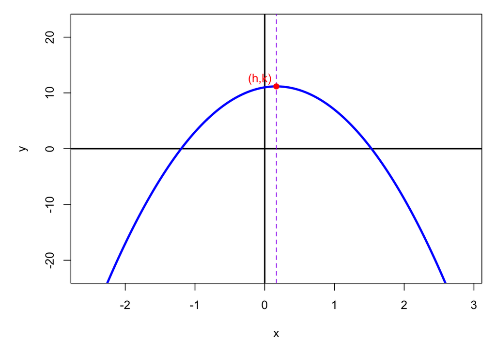

Using [the geometric significance of the quadratic formula](https://en.wikipedia.org/wiki/Quadratic_formula#Geometric_significance), calculate $h$, the horizontal coordinate of the vertex. *The tolerance is $\pm 0.01$.*

# Solution

Look at the quadratic formula, which tells us if our quadratic function is in standard form, like $y=ax^2+bx+c$, then:

$$\text{roots of quadratic function} ~=~
\frac{-b}{2a}\pm\frac{\sqrt{b^2-4ac}}{2a}$$

We were given a quadratic function in standard form. Identify the parameters.

- The quadratic coefficient: $a=-6$
- The linear coefficient: $b=2$
- The constant: $c=11$

The [the geometric significance of the quadratic formula](https://en.wikipedia.org/wiki/Quadratic_formula#Geometric_significance) tells us that $h=\frac{-b}{2a}$ and the distance of the roots to the axis of symmetry is $\frac{\sqrt{b^2-4ac}}{2a}$. Use the formula to calculate $h$.

$$\begin{align}
h &= \frac{-b}{2a} \\\\
&= \frac{-(2)}{2(-6)} \\\\
&= 0.1666667
\end{align}$$

- The axis of symmetry is line $x=0.1666667$.
- The vertex is point $(0.1666667,\,11.1666667)$

# Meta-information

extype: num exsolution: 0.1666667 exname: quad_AOS_from_standard extol: 0.01